# Assignment 3: Model comparison

Eszter Palócz

In this lab assignment you are going to work with (simulated) data related to perioperative pain and its psychological and hormonal predictors. In the assignment you will assess the added benefit of including some psychological and hormonal predictors to the already established demographic predictors of pain.

In this assignment you will set up a hierarchical regression model to predict postoperative pain after wisdom tooth surgery.

# Research problem

The amount of pain experienced around and after surgeries are highly variable between and within individuals. In order to improve surgical pain management regimens we need to understand what influences pain around surgical procedures and predict the amount of pain an individual will experience.

Your first study in this area is related to assessing the influence of trait and state psychological measures on pain, and to see whether taking into account these variables can improve our understanding of postoperative pain.

# Procedures and measures

Use the data file called ‘assignment_3_dataset’, from the ‘data/’ folder.

You have collected data from 160 adults who were scheduled to undergo surgical extraction of the third mandibular molar (wisdom tooth surgery). Patients filled out a form in the waiting room before their surgery. The form contained questions about their sex, age, and weight, and psychological questionnaires assessing anxiety, pain catastrophizing, and mindfulness (see descriptions below). You also got blood samples and saliva samples from participants in the waiting room 5 minutes before their operations to determine the serum (a component of the blood) and salivary cortisol levels of participants. Participants were contacted 5 hours after the surgery to see how much pain they were experiencing. The **level of pain** at that moment was recorded using a numerical rating scale using a **scale of 0 to 10**, where 0 means “no pain” and 10 means “worst pain I can imagine”.

**The State Trait Anxiety Inventory:** T measures trait anxiety on a scale of 20 to 80, higher scores mean higher anxiety. Anxiety has been found in many studies to positively correlate with the level of pain experienced. This is **variable STAI_trait** in the dataset.

**The Pain Catastrophizing Scale** measures the extent of pain catastrophizing, which is characterized by a tendency to magnify the threat value of a pain stimulus and to feel helpless in the presence of pain, as well as by a relative inability to prevent or inhibit pain-related thoughts in anticipation of, during, or following a painful event. The total score on this scale ranges from 0 to 52, higher scores mean higher catastrophizing. Pain catastrophizing is one of the well-established predictors of clinical pain. This is **variable pain_cat** in the dataset.

**The Mindful Attention Awareness Scale (MAAS)** measures dispositional mindfulness, which may be described as a tendency to turn attention to present-moment experiences in an open, non-judgmental way. The MAAS total score ranges from 1 to 6 (an average of the item scores), with higher scores representing higher dispositional mindfulness. Trait mindfulness has been theorized to serve as a protective factor against pain, as the individual would be more objective about their pain experience and tend to associate less discomfort, despair, and hopelessness to the pain-related sensations. This is **variable mindfulness** in the dataset.

**Cortisol** is a stress hormone associated with acute and chronic stress. Cortisol levels are thought to be positively associated with pain experience. Cortisol can be **measured from both blood and the saliva**, although, serum cortisol is often regarded in medical research as more reliably related to stress (serum is a component of the blood plasma). These are **variables cortisol_serum**, and **cortisol_saliva** in the dataset.

# Research question

Previous studies and meta-analyses showed that age and sex are often predictors of pain (age is negatively associated with pain, while sex is a predictor more dependent on the type of the procedure). You would like to determine the extent to which taking into account psychological and hormonal variables aside from the already used demographic variables would improve our understanding of postoperative pain.

To answer this research question you will **need to compare two models** (with a hierarchical regression). The **simpler model** should contain **age and sex as predictors of pain**, while the **more complex model** should contain the **predictors: age, sex, STAI, pain catastrophizing, mindfulness, and cortisol measures**. Notice that the predictors used in the simpler model are a subset of the predictors used in more complex model. **You will have to do model comparison to assess whether substantial new information was gained about pain in the more complex model compared to the simpler model.**

# What to report

As usual, before you can interpret your model, you will need to run data and model diagnostics. First, check the variables included in the more complex model (age, sex, STAI, pain catastrophizing, mindfulness, and cortisol measures as predictors, and pain as an outcome) for **coding errors**, and the model itself for **influential outliers** (for example using Cook’s distance). Furthermore, check the final model to see if the **assumptions of linear regression hold true**, that is, **normality** (of the residuals), **linearity** (of the relationship), **homogeneity of variance** (also called homoscedasticity) and that there is no excess **multicollinearity** (“uncorrelated predictors” in Navarro’s words). If you find anything amiss during these checks, make the appropriate decision or correction and report your findings and actions in your report.

**Note:** If you do any changes, such as exclude cases, or exclude predictors from the model, you will have to re-run the above checks for your final data and model.

Report the results of the simpler model and the more complex model. For both models you should report the model test statistics (adj.R2, F, df, and p value). Also, report the statistics describing the coefficients of the predictors in a table format (unstandardized regression coefficients and 95% confidence intervals, standardized regression coefficients (B and Beta values), and p values).

Write up the regression equation of the more complex model in the form of 𝑌 = 𝑏0 + 𝑏1 ∗ X1 + 𝑏2 ∗ X2 +…+ bn * Xn, in which you use the actual regression coefficients of your models. (b0 stands for the intercept and b1, b2 … bn stand for the model coefficients for each of the predictors, and X1, X2, … Xn denote the predictors).

Compare the two models in terms of how much variance they explain of pain’s variability in the sample. Report Akaike information criterion (AIC) for both models and the F test statistic and p value of the likelihood ratio test comparing the two models.

# What to discuss

In your discussion of the findings, briefly interpret the results of the above analyses, and indicate whether you think that anything was gained by including the psychological and hormone measures in the model.

# Solution

## Data and model diagnostics

### Data diagnostics

```r
# Viewing the first few rows of the dataset
head(paindata)
```

```
## # A tibble: 6 × 12
##   ID     pain sex      age STAI_trait pain_cat cortisol_serum cortisol_saliva
##   <chr> <dbl> <chr>  <dbl>      <dbl>    <dbl>          <dbl>           <dbl>
## 1 ID_1      5 female    38         39       25           4.67            4.78
## 2 ID_2      4 female    36         46       31           6.01            6.71
## 3 ID_3      5 female    51         49       32           5.18            4.75
## 4 ID_4      7 female    39         48       41           6.65            6.68
## 5 ID_5      4 male      48         36       26           2.95            3.2
## 6 ID_6      6 female    45         37       28           4.32            4.36
## # ℹ 4 more variables: mindfulness <dbl>, weight <dbl>, IQ <dbl>,
## #   household_income <dbl>
```

```r
# Checking the structure of the data (data types, missing values)
str(paindata)
```

```
## tibble [160 × 12] (S3: tbl_df/tbl/data.frame)
##  $ ID              : chr [1:160] "ID_1" "ID_2" "ID_3" "ID_4" ...
##  $ pain            : num [1:160] 5 4 5 7 4 6 4 5 4 5 ...
##  $ sex             : chr [1:160] "female" "female" "female" "female" ...
##  $ age             : num [1:160] 38 36 51 39 48 45 45 35 39 33 ...
##  $ STAI_trait      : num [1:160] 39 46 49 48 36 37 34 39 31 38 ...
##  $ pain_cat        : num [1:160] 25 31 32 41 26 28 22 32 27 36 ...
##  $ cortisol_serum  : num [1:160] 4.67 6.01 5.18 6.65 2.95 4.32 5.32 5.26 3.36 5.96 ...
##  $ cortisol_saliva : num [1:160] 4.78 6.71 4.75 6.68 3.2 4.36 5.19 5.53 3.3 5.78 ...
##  $ mindfulness     : num [1:160] 3.83 2.82 3.93 1.9 4.39 3.01 4.97 2.95 3.43 1.85 ...
##  $ weight          : num [1:160] 62.1 97.1 79 78.5 76.9 ...
##  $ IQ              : num [1:160] 99 71 97 97 129 115 74 98 93 76 ...
##  $ household_income: num [1:160] 52505 64993 68598 47822 100580 ...
```

```r
# Dropping variables that are not needed for the analysis (weight, IQ, household income)
paindata <- paindata %>% dplyr::select(-weight, -IQ, -household_income)

# Checking the new dataset again
head(paindata)
```

```
## # A tibble: 6 × 9
##   ID     pain sex      age STAI_trait pain_cat cortisol_serum cortisol_saliva
##   <chr> <dbl> <chr>  <dbl>      <dbl>    <dbl>          <dbl>           <dbl>
## 1 ID_1      5 female    38         39       25           4.67            4.78
## 2 ID_2      4 female    36         46       31           6.01            6.71
## 3 ID_3      5 female    51         49       32           5.18            4.75
## 4 ID_4      7 female    39         48       41           6.65            6.68
## 5 ID_5      4 male      48         36       26           2.95            3.2
## 6 ID_6      6 female    45         37       28           4.32            4.36
## # ℹ 1 more variable: mindfulness <dbl>
```

```r
str(paindata)
```

```
## tibble [160 × 9] (S3: tbl_df/tbl/data.frame)
##  $ ID             : chr [1:160] "ID_1" "ID_2" "ID_3" "ID_4" ...
##  $ pain           : num [1:160] 5 4 5 7 4 6 4 5 4 5 ...
##  $ sex            : chr [1:160] "female" "female" "female" "female" ...
##  $ age            : num [1:160] 38 36 51 39 48 45 45 35 39 33 ...
##  $ STAI_trait     : num [1:160] 39 46 49 48 36 37 34 39 31 38 ...
##  $ pain_cat       : num [1:160] 25 31 32 41 26 28 22 32 27 36 ...
##  $ cortisol_serum : num [1:160] 4.67 6.01 5.18 6.65 2.95 4.32 5.32 5.26 3.36 5.96 ...
##  $ cortisol_saliva: num [1:160] 4.78 6.71 4.75 6.68 3.2 4.36 5.19 5.53 3.3 5.78 ...
##  $ mindfulness    : num [1:160] 3.83 2.82 3.93 1.9 4.39 3.01 4.97 2.95 3.43 1.85 ...
```

```r
summary(paindata)
```

```
##       ID                 pain            sex                 age
##  Length:160         Min.   : 1.000   Length:160         Min.   :24.00
##  Class :character   1st Qu.: 4.000   Class :character   1st Qu.:38.00
##  Mode  :character   Median : 5.000   Mode  :character   Median :41.00
##                     Mean   : 5.194                      Mean   :40.74
##                     3rd Qu.: 6.000                      3rd Qu.:44.00
##                     Max.   :50.000                      Max.   :53.00
##    STAI_trait       pain_cat     cortisol_serum  cortisol_saliva
##  Min.   :26.00   Min.   :14.00   Min.   :2.700   Min.   :2.530
##  1st Qu.:37.00   1st Qu.:27.00   1st Qu.:4.268   1st Qu.:4.120
##  Median :40.00   Median :30.00   Median :4.995   Median :5.035
##  Mean   :40.09   Mean   :29.88   Mean   :4.941   Mean   :4.952
##  3rd Qu.:43.00   3rd Qu.:32.25   3rd Qu.:5.633   3rd Qu.:5.753
##  Max.   :52.00   Max.   :42.00   Max.   :7.110   Max.   :7.190
##   mindfulness
##  Min.   :1.000
##  1st Qu.:2.595
##  Median :3.115
##  Mean   :3.204
##  3rd Qu.:3.830
##  Max.   :6.220
```

```r
# Changing the variable sex to factor
paindata$sex <- as.factor(paindata$sex)

# Mindfulness scale is 1 to 6, however there is a value over 6. Filtering the values over 6
paindata <- paindata %>%
 filter(mindfulness <= 6)

summary(paindata$mindfulness)
```

```
##    Min. 1st Qu.  Median    Mean 3rd Qu.    Max.
##   1.000   2.590   3.110   3.186   3.830   5.630
```

```r
# Checking for missing values
colSums(is.na(paindata))
```

```
##              ID            pain             sex             age      STAI_trait
##               0               0               0               0               0
##        pain_cat  cortisol_serum cortisol_saliva     mindfulness
##               0               0               0               0
```

There are no missing values in the data.

### Descriptive statistics for variables

```r
# Summary (descriptive) statistics for all variables
summary(paindata)
```

```
##       ID                 pain            sex          age
##  Length:159         Min.   : 1.000   female:83   Min.   :24.00
##  Class :character   1st Qu.: 4.000   male  :75   1st Qu.:38.00
##  Mode  :character   Median : 5.000   woman : 1   Median :41.00
##                     Mean   : 5.214               Mean   :40.69
##                     3rd Qu.: 6.000               3rd Qu.:44.00
##                     Max.   :50.000               Max.   :53.00
##    STAI_trait       pain_cat     cortisol_serum  cortisol_saliva
##  Min.   :26.00   Min.   :14.00   Min.   :2.700   Min.   :2.530
##  1st Qu.:37.00   1st Qu.:27.00   1st Qu.:4.270   1st Qu.:4.170
##  Median :40.00   Median :30.00   Median :5.010   Median :5.050
##  Mean   :40.18   Mean   :29.97   Mean   :4.948   Mean   :4.959
##  3rd Qu.:43.00   3rd Qu.:32.50   3rd Qu.:5.645   3rd Qu.:5.755
##  Max.   :52.00   Max.   :42.00   Max.   :7.110   Max.   :7.190
##   mindfulness
##  Min.   :1.000
##  1st Qu.:2.590
##  Median :3.110
##  Mean   :3.186
##  3rd Qu.:3.830
##  Max.   :5.630
```

## Running an exploratory data analysis (EDA) to investigate the dataset.

### Checking for the distribution of the data

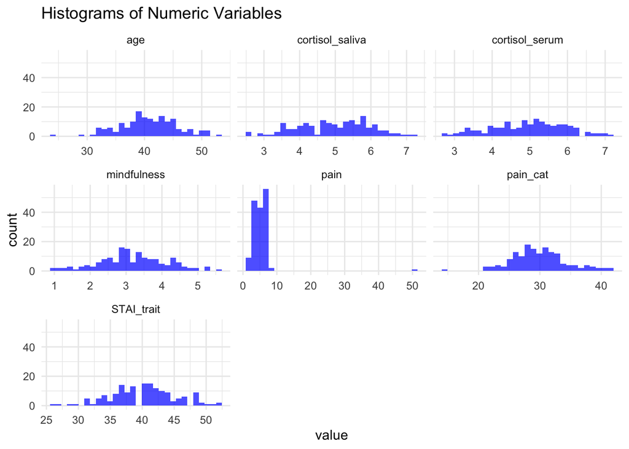

```r
# Histogram of numeric variables
paindata %>%
  select_if(is.numeric) %>%  # Select numeric columns
  gather() %>%
  ggplot(aes(x=value)) +
  geom_histogram(bins = 30, fill = "blue", alpha = 0.7) +
  facet_wrap(~key, scales = "free_x") +
  theme_minimal() +
  labs(title = "Histograms of Numeric Variables")
```

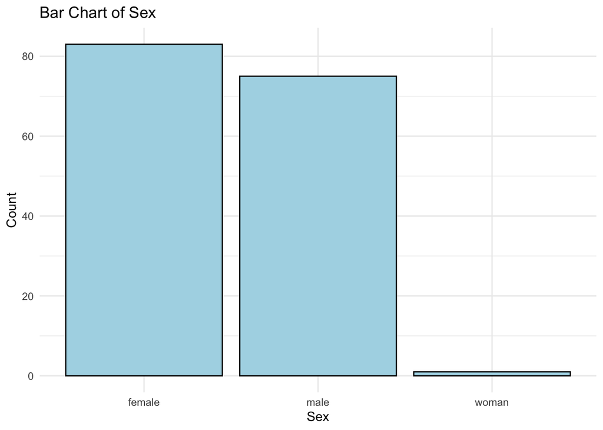

```r
# Histogram of the variable sex
ggplot(paindata, aes(x = sex)) +
  geom_bar(fill = "lightblue", color = "black") +
  labs(title = "Bar Chart of Sex", x = "Sex", y = "Count") +
  theme_minimal()
```

The histograms and boxplots of variables show that there are some potential outliers that need to be explored further (variable: pain).

The histogram of the variable ‘sex’ shows that there is an element coded as “woman”, which seems to be a coding error and needs to be put under “female”.

### Detecting outliers

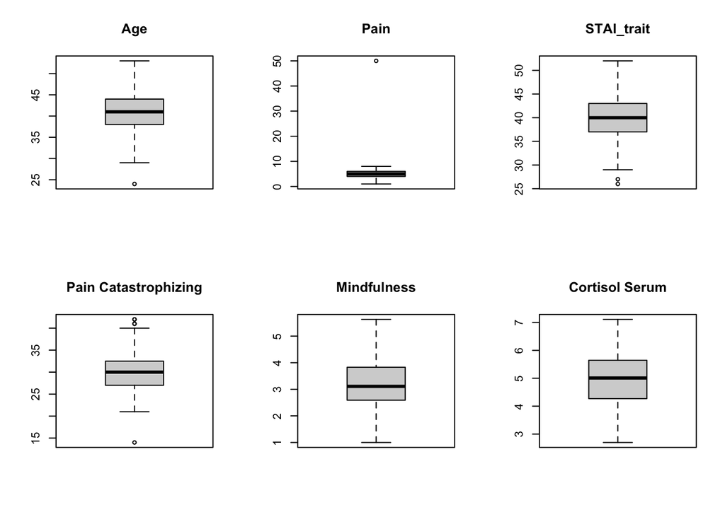

```r
# Boxplots to detect outliers
par(mfrow = c(2, 3))
boxplot(paindata$age, main = "Age")
boxplot(paindata$pain, main = "Pain")
boxplot(paindata$STAI_trait, main = "STAI_trait")
boxplot(paindata$pain_cat, main = "Pain Catastrophizing")
boxplot(paindata$mindfulness, main = "Mindfulness")
boxplot(paindata$cortisol_serum, main = "Cortisol Serum")
```

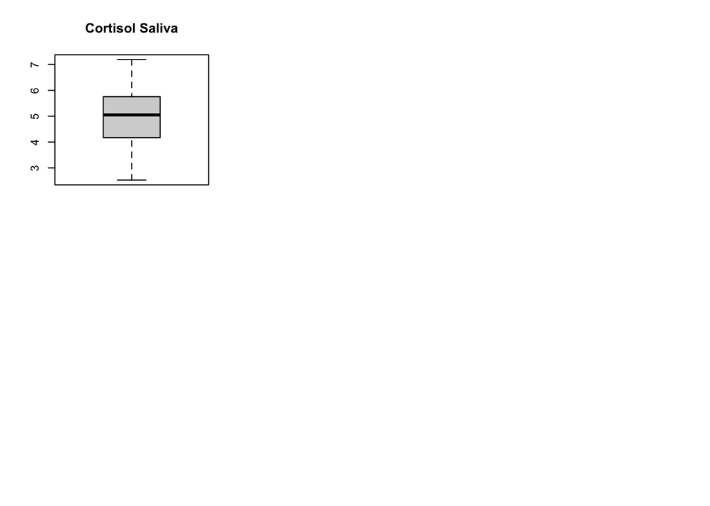

```r
boxplot(paindata$cortisol_saliva, main = "Cortisol Saliva")
```

Further explorations with boxplots show an extreme value in the variable pain which seems to be a coding error. Next, influential outliers will be checked with Cook’s distance.

### Checking influential outliers on the complex model

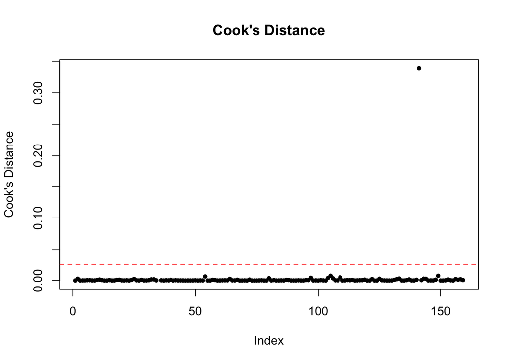

```r
# Fitting the complex model (age, sex, STAI_trait, pain_cat, mindfulness, cortisol_serum, cortisol_saliva)
complex_model <- lm(pain ~ age + sex + STAI_trait + pain_cat + mindfulness + cortisol_serum + cortisol_saliva, data = paindata)

# Calculating Cook's distance
cooksd <- cooks.distance(complex_model)

# Cook's distance - plot
plot(cooksd, main = "Cook's Distance", ylab = "Cook's Distance", pch = 20)
abline(h = 4 / nrow(paindata), col = "red", lty = 2)  # Threshold line at 4/n
```

```r
# Identify influential points
influential_points <- which(cooksd > (4 / nrow(paindata)))
paindata[influential_points, ]
```

```
## # A tibble: 1 × 9
##   ID      pain sex      age STAI_trait pain_cat cortisol_serum cortisol_saliva
##   <chr>  <dbl> <fct>  <dbl>      <dbl>    <dbl>          <dbl>           <dbl>
## 1 ID_142    50 female    41         44       30           5.85            6.14
## # ℹ 1 more variable: mindfulness <dbl>
```

As expected, it was found with Cook’s distance that the variable pain includes an extreme value that is a coding error, therefore this value needs to be filtered (below).

#### Correcting coding errors

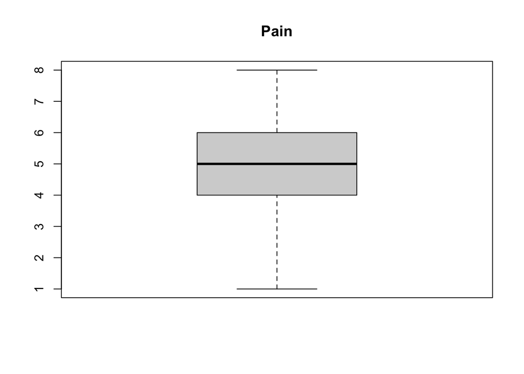

```r
# Correcting the coding error in sex
paindata <- paindata %>%
  mutate(sex = dplyr::recode(sex, "woman" = "female"))

# Excluding the extreme value from pain that is a coding error
paindata_filtered <- paindata %>% filter(pain != 50)

# Checking new boxplot for pain
boxplot(paindata_filtered$pain, main = "Pain")
```

### Model diagnostics

#### Building the more complex model

In order to test the more complex model for outliers and to test the assumptions first build the model.

```r
# Fitting the model without the outlier
model_filtered <- lm(pain ~ age + sex + STAI_trait + pain_cat + mindfulness + cortisol_serum + cortisol_saliva, data = paindata_filtered)

# Model summary
summary(model_filtered)
```

```
##
## Call:
## lm(formula = pain ~ age + sex + STAI_trait + pain_cat + mindfulness +
##     cortisol_serum + cortisol_saliva, data = paindata_filtered)
##
## Residuals:
##     Min      1Q  Median      3Q     Max
## -3.2406 -0.7463 -0.0537  0.7906  2.9380
##
## Coefficients:
##                 Estimate Std. Error t value Pr(>|t|)
## (Intercept)      1.29880    1.72907   0.751  0.45374
## age             -0.02142    0.02447  -0.875  0.38292
## sexmale          0.32267    0.21118   1.528  0.12863
## STAI_trait      -0.02814    0.02821  -0.998  0.32010
## pain_cat         0.09370    0.02889   3.243  0.00146 **
## mindfulness     -0.11768    0.12620  -0.933  0.35257
## cortisol_serum   0.16818    0.24576   0.684  0.49482
## cortisol_saliva  0.44738    0.25296   1.769  0.07900 .
## ---
## Signif. codes:  0 '***' 0.001 '**' 0.01 '*' 0.05 '.' 0.1 ' ' 1
##
## Residual standard error: 1.244 on 150 degrees of freedom
## Multiple R-squared:  0.3516, Adjusted R-squared:  0.3213
## F-statistic: 11.62 on 7 and 150 DF,  p-value: 9.351e-12
```

#### Checking for influential outliers in the complex, filtered model

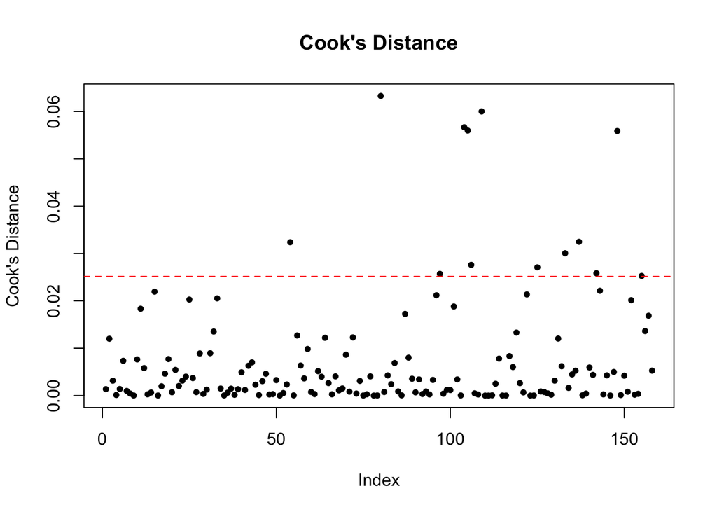

```r
# Calculate Cook's distance
cooksd <- cooks.distance(model_filtered)

# Plot Cook's distance
plot(cooksd, main = "Cook's Distance", ylab = "Cook's Distance", pch = 20)
abline(h = 4 / nrow(paindata), col = "red", lty = 2)  # Threshold line at 4/n
```

```r
# Identify influential points
influential_points <- which(cooksd > (4 / nrow(paindata)))
paindata[influential_points, ]
```

```
## # A tibble: 13 × 9
##    ID      pain sex      age STAI_trait pain_cat cortisol_serum cortisol_saliva
##    <chr>  <dbl> <fct>  <dbl>      <dbl>    <dbl>          <dbl>           <dbl>
##  1 ID_55      2 female    44         47       28           5.09            5.77
##  2 ID_81      8 male      46         37       24           6.78            6.37
##  3 ID_98      3 female    33         41       31           5.44            6.17
##  4 ID_105     7 female    38         38       21           5.46            4.9
##  5 ID_106     1 female    43         50       26           3.99            3.99
##  6 ID_107     2 female    39         34       30           4.77            4.99
##  7 ID_110     4 male      37         41       31           6.9             6.29
##  8 ID_126     6 female    47         39       32           4.85            3.57
##  9 ID_134     7 male      39         36       39           3.65            3.92
## 10 ID_138     6 female    47         41       24           4.14            5.06
## 11 ID_143     4 female    44         41       33           5.24            4.96
## 12 ID_149     5 female    37         32       30           6.21            6.14
## 13 ID_156     5 female    41         39       26           4.9             5.17
## # ℹ 1 more variable: mindfulness <dbl>
```

### Checking assumptions

#### Checking the normality assumption.

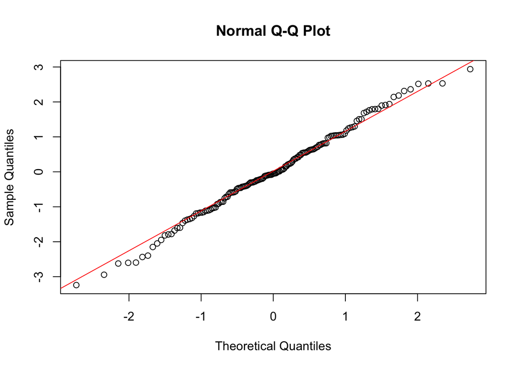

```r
# Residuals from the complex model
residuals_complex <- residuals(model_filtered)

# Q-Q plot of residuals
qqnorm(residuals_complex)
qqline(residuals_complex, col = "red")
```

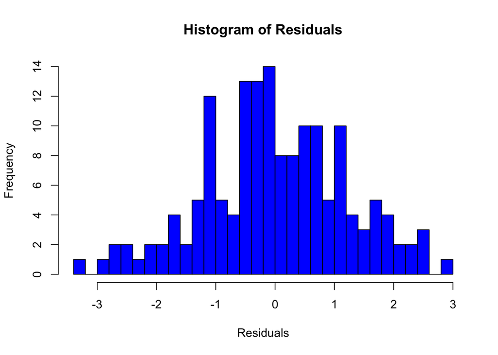

```r
# Histogram of residuals
hist(residuals_complex, main = "Histogram of Residuals", xlab = "Residuals", col = "blue", breaks = 30)
```

```r
# Shapiro-Wilk test
shapiro.test(residuals(model_filtered))
```

```
##
##  Shapiro-Wilk normality test
##
## data:  residuals(model_filtered)
## W = 0.99422, p-value = 0.788
```

The Q-Q plot and histogram, and the results of the Shapiro-Wilk test show that the data is approximately normally distributed (the data points mostly follow the linear red line with some small deviations).

### Checking the linearity assumption.

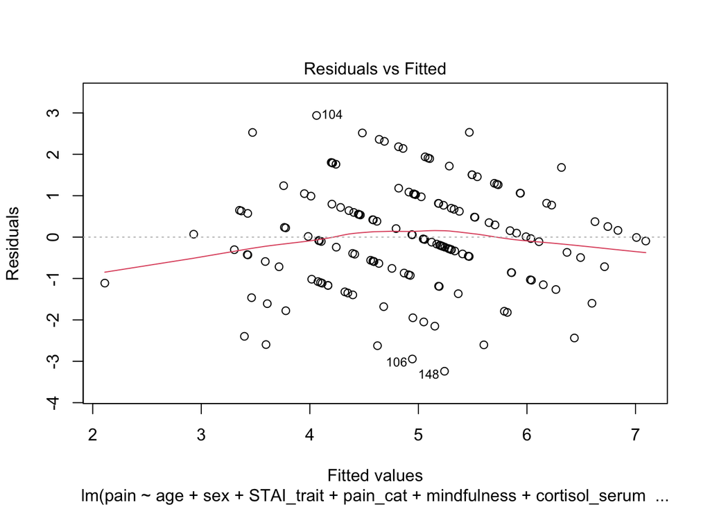

```r
plot(model_filtered, which = 1)
```

The assumption of linearity is met.

### Checking the homoscedasticty assumption (homogeneity of variance).

```r
bptest(model_filtered)
```

```
##
##  studentized Breusch-Pagan test
##
## data:  model_filtered
## BP = 6.7628, df = 7, p-value = 0.454
```

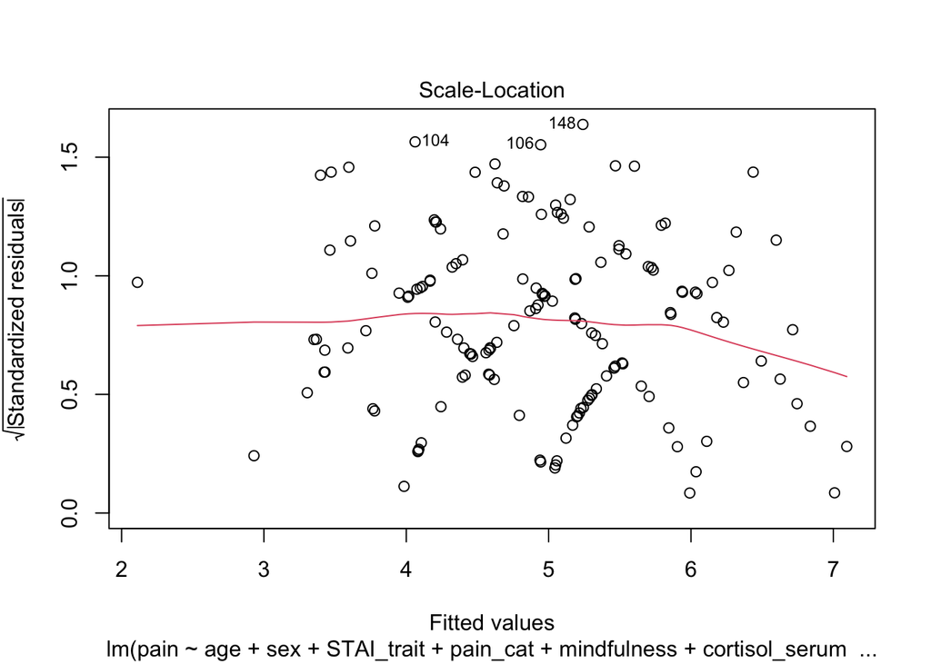

```r
plot(model_filtered, which = 3)
```

The assumption of homoscedasticity is met.

### Checking the multicollinearity assumption.

Some info about VIF: https://statisticalhorizons.com/multicollinearity http://blog.minitab.com/blog/understanding-statistics/handling-multicollinearity-in-regression-analysis

```r
library(car)
vif(model_filtered)
```

```
##             age             sex      STAI_trait        pain_cat     mindfulness
##        1.537752        1.134642        2.056568        1.836336        1.466876
##  cortisol_serum cortisol_saliva
##        6.020413        6.594781
```

The results of the multicollinearity check suggest that two variables (cortisol_serum and cortisol_saliva) exceed the threshold of VIF of 5, which indicates moderate to high multicollinearity between these two variables, therefore they are most likely strongly correlated with each other. In the description of the cortisol variables, it is suggested serum cortisol is found to be more reliably related to stress in medical research, therefore I will keep this variable and drop cortisol_saliva from the model.

### Making decision based on model diagnostics

Based on the assumption tests, I decided to drop a predictor variable (cortisol_saliva). I will create the updated model.

```r
# Updated model, without cortisol_saliva
model_filtered_updated <- lm(pain ~ age + sex + STAI_trait + pain_cat + mindfulness + cortisol_serum, data = paindata_filtered)

summary(model_filtered_updated)
```

```
##
## Call:
## lm(formula = pain ~ age + sex + STAI_trait + pain_cat + mindfulness +
##     cortisol_serum, data = paindata_filtered)
##
## Residuals:
##      Min       1Q   Median       3Q      Max
## -3.00019 -0.82040 -0.02332  0.81886  2.63201
##
## Coefficients:
##                Estimate Std. Error t value Pr(>|t|)
## (Intercept)     1.94499    1.70189   1.143  0.25491
## age            -0.03400    0.02358  -1.442  0.15145
## sexmale         0.31570    0.21262   1.485  0.13969
## STAI_trait     -0.01324    0.02711  -0.488  0.62600
## pain_cat        0.08338    0.02849   2.926  0.00396 **
## mindfulness    -0.13623    0.12665  -1.076  0.28379
## cortisol_serum  0.54341    0.12490   4.351 2.49e-05 ***
## ---
## Signif. codes:  0 '***' 0.001 '**' 0.01 '*' 0.05 '.' 0.1 ' ' 1
##
## Residual standard error: 1.253 on 151 degrees of freedom
## Multiple R-squared:  0.3381, Adjusted R-squared:  0.3118
## F-statistic: 12.85 on 6 and 151 DF,  p-value: 1.054e-11
```

#### Checking outliers of the updated model

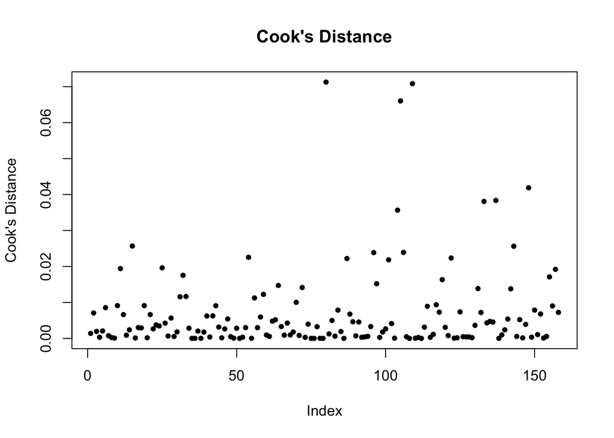

```r
cooksd <- cooks.distance(model_filtered_updated)

original_data <- model_filtered_updated$model_filtered

plot(cooksd, main = "Cook's Distance", ylab = "Cook's Distance", pch = 20)
abline(h = 4 / nrow(original_data), col = "red", lty = 2)
```

```r
influential_points <- which(cooksd > (4 / nrow(original_data)))
original_data[influential_points, ]
```

[output not shown]

#### Checking assumptions of the updated model

Normality assumption

```r
# Calculating residuals
residuals_complex <- residuals(model_filtered_updated)

# Shapiro-Wilk test
shapiro.test(residuals(model_filtered_updated))
```

```
##
##  Shapiro-Wilk normality test
##
## data:  residuals(model_filtered_updated)
## W = 0.99275, p-value = 0.6118
```

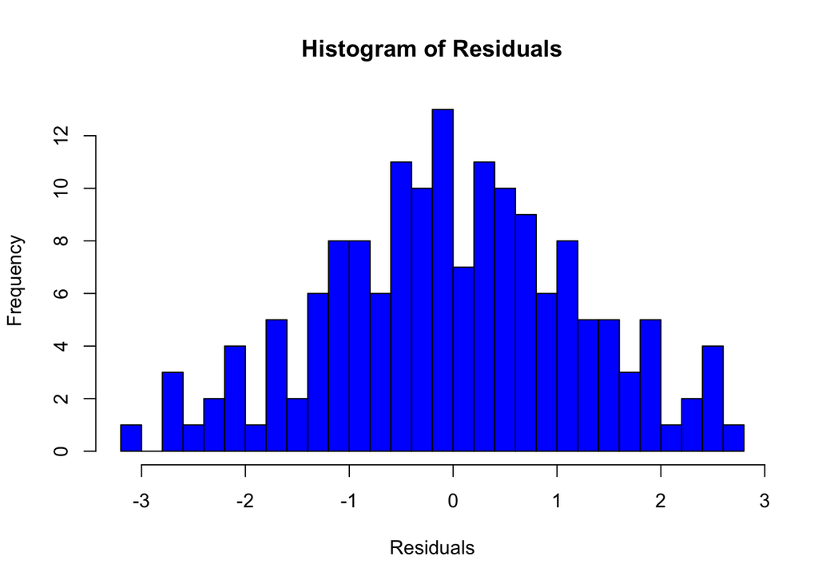

```r
# Histogram of residuals
hist(residuals_complex, main = "Histogram of Residuals", xlab = "Residuals", col = "blue", breaks = 30)
```

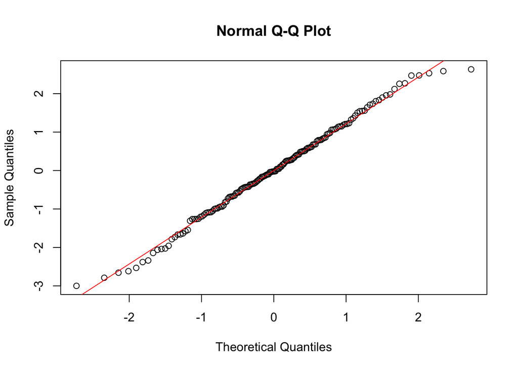

```r
# Q-Q plot of residuals
qqnorm(residuals_complex)
qqline(residuals_complex, col = "red")
```

The assumption of normality is met.

### Linearity assumption

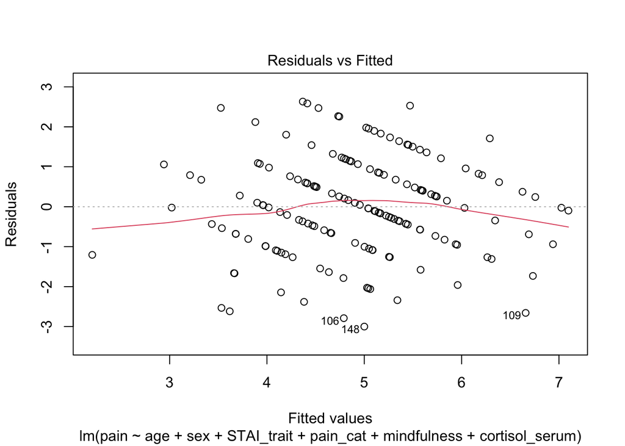

```r
plot(model_filtered_updated, which = 1)
```

```r
raintest(model_filtered_updated)
```

```
##
##  Rainbow test
##
## data:  model_filtered_updated
## Rain = 0.956, df1 = 79, df2 = 72, p-value = 0.5786
```

The assumption of linearity is met.